# Generalized Protective Momentum 阅读报告

## 一、简介

Generalized Protective Momentum（GPM）是动量投资的一种，是由JW Keuning 和 Wouter Keller发展他们的Protective Asset Allocation（PAA）所得来。他们在PAA的基础之上额外考虑了资产之间的相关性，把相关系数correlation加入了动量指标中。

# 二、构建原理

*GPM 与 PAA 均为月度交易策略

### 1. PAA

作者在关于Protective Asset Allocation的论文中，详细解释了如何通过SMA (Simple Moving Average) filter 和由其求出的momentum indicator（MOM(L)）来构建动量策略，达到极高的保护性与熊市回避能力。

在论文中，主要使用的动量指标是SMA。作者在文中说明了他选择SMA而不是RET的原因（SMA可包含更多信息且SMA所得结果更佳），并强调了文章主要用意是证明这种absolute momentum和relative momentum同时使用的策略达成的高保护性。推测其他的绝对动量指标应该也存在拓展为高保护性动量策略的可能性。 SMA由资产价格得来，文中使用SMA(12)代表过去12个月的价格的SMA。

使用SMA求出的不同资产的momentum indicator（MOM(L)）。

公式为： \begin{equation} MOM(L) = p_0 / SMA(L) - 1 \label{eq:当前公式名} \end{equation}

p0为当期的资产价格，SMA(L)为look back period的SMA。

通过MOM(L)是否大于0来定义这个资产是good asset或bad asset，并通过good asset的数量n，所有risky asset的数量N来求得bond fraction（BF），即投资于无风险资产的比例： \begin{equation} BF = (N-n)/(N-n_1) \end{equation} \begin{equation} n_1 = a*N/4 \end{equation} 其中a为保护因子，可取值0，1，2。若n<=n_1 则取BF=100%

我们确定TOP个动量指标MOM最高的good asset为我们要投资的风险资产（TOP<n），等权重地将风险资产部分的资金投资于这些资产。

### 2、GPM

GPM的构建，是在PAA之上增加了correlation的使用。GPM使用的动量指标由1，3，6，12月资产月收益的平均值以及12个月内与其他资产的相关系数求得。公式如下：  
ri = average of the 1, 3, 6 and 12 month return of that asset  
ci = 12-month correlation between that asset and the equal-weight return of the 12 risk asset classes (rebalanced monthly)  
zi = ri * (1 – ci)

在作者的论文中还测试了以ri / ( 1 + ci )作为动量因子的计算方法。

之后的步骤与PAA相同，只是把判断标准从MOM(L)变为了zi是否大于0。

# 三、资产选择

### 1、无风险资产的选择

在PAA中作者选择了IEF作为无风险资产，并详细叙述了原因：比SHY、货币更高的收益（年化5.3%），以及比TLT更低的波动率。虽然TLT作为国债ETF可达到11.5%的年化收益，但由于此策略的中心是“protective”，故为了达到更好的保护效果与风险控制，并没有选择TLT。  
在GPM的回测中，文章也沿用了这个无风险资产的选择。

### 2、风险资产的选择

在PAA中，风险资产的范围需要涵盖广泛，才能达到作者意图的“通过广阔的市场中不同资产的相对动量来判断市场大环境为牛市还是熊市”的目标。故作者选择了12种风险资产来做回测，分别为

- SPDR S&P 500 Trust ETF (NYSEARCA:SPY)
- PowerShares QQQ Trust ETF (NASDAQ:QQQ)
- iShares Russell 2000 ETF (NYSEARCA:IWM)
- iShares MSCI Emerging Markets ETF (NYSEARCA:EEM)
- Vanguard FTSE Europe ETF (NYSEARCA:VGK)
- iShares MSCI Japan ETF (NYSEARCA:EWJ)
- iShares U.S. Real Estate ETF (NYSEARCA:IYR)
- iShares S&P GSCI Commodity-Indexed Trust ETF (NYSEARCA:GSG)
- SPDR Gold Trust ETF (NYSEARCA:GLD)
- iShares 20+ Year Treasury Bond ETF (NASDAQ:TLT)
- iShares iBoxx \$ High Yield Corporate Bond ETF (NYSEARCA:HYG)
- iShares iBoxx \$ Investment Grade Corporate Bond ETF (NYSEARCA:LQD)

在JW Keuning 和 Wouter Keller关于GPM的回测中，他们也沿用了同样的风险资产，来代表12个国际市场。在allocation smartly的回测中，将IYR，GSG换为了US real estate (VNQ), commodities (DBC)。不过大体上均是相同的资产。

# 四、回测表现

### 1. PAA

使用Dec 1970 – Dec 2015之间45年的月度数据进行回测。基础数据为全收益月终价格。为了减小跟踪误差，对真实ETF进行了重新构建，故又引入了管理费用。

将数据集平均分为1971-1992与1993-2015两个时间段分别作为in-sample(IS)与out-of-sample(OS)来做测试。首先使用IS数据测试找出策略表现与参数（4个lookback period，3个a值，6个TOP值）大致关系，之后使用较佳的参数与OS数据来进行测试。作者在第一轮测试后决定使用12个月的lookback period（确保低换仓频率）和TOP=6（有最小的波动和回撤）进行测试。

指标说明：  
Return (CAGR)-R,  
Volatility-V,  
Max Drawdown-D,  
1 year rolling return Win rate (the percentage of time that the return is worse than a 1y term deposit in one year) - Win0,  
1y rolling negative returns (the percentage of time that the return is below -5% in one year) - Win5,  
Sharp Ratio - SR,  
MAR - Return/Max Drawdown，

而在最后的Bond Fraction与SPY收益走势图对比中也可以看出，PAA可以十分有效地避开熊市，在熊市时投资比例基本均是100%的无风险资产(Bond)。

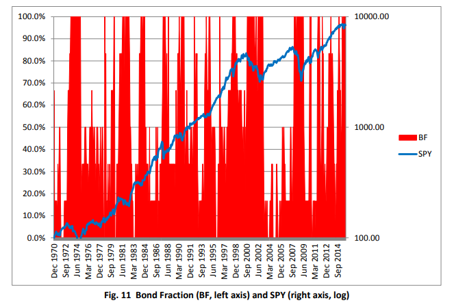

### 2. GPM

作者的回测中对比了GPM与PAA的表现，结果如图：

[figure not shown]

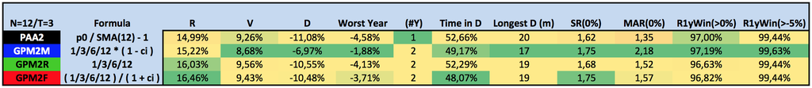

*此项回测为忽略交易费用、滑点、税费等的理想测试。  
从中我们可以看出，虽然整体差距不大，但加入了correlation的GPM的表现仍然超过了普通PAA，且乘积/除法两种计算方式中乘积形式（GPM2M）的保护效果更佳。

AllocateSmartly的回测是以60/40组合为基准，回测结果也十分优秀。

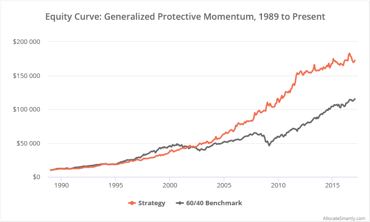

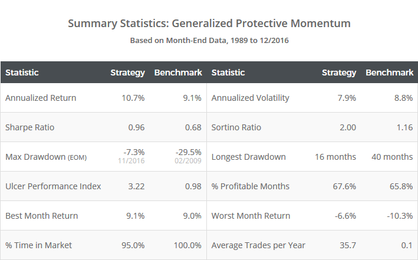

# 五、总结

通过回测证实，PAA与GPM均有很强的保护效果，且长期均可获得优于基准的收益表现。GPM由于在选择风险资产时考虑了资产之间的相关性，可获得更加分散无相关性的组合，从而更理想地测定市场状态、控制风险。

关于PAA的原论文有很多对于回测结果严谨性的说明。如关于IS、OS时期无风险利率、基准收益不一致（IS时rf=7.5%，60/40基准年均收益率12%；OS时rf=2.5%，60/40基准年均收益率8.5%）导致OS回测结果不是很理想，是正常现象而不是数据透视偏差。不过这些问题都对最终结果没有太显著的影响。